# TSCI 5050: Introduction to Data Science: Homework 2

Alex F. Bokov

10/31/2017

Thank you for taking this class. I have reviewed this homework and given it a passing grade. Please see my detailed feedback below. In the HTML version it will be highlighted in yellow.

Please copy this file to `YOURNAME_hw02.R` then commit it as usual by issuing the following commands in the bash shell (not in R):

`git co YOURBRANCH`

`git ci YOURNAME_hw02.R -m "Added homework #2"`

`git push`

Repeat the above whenver you make changes to this file. You may work with other people on this homework, just make sure to credit each other on your individual homework sheets.

First we load the `run.R` file using the `source('run.R')` command but we don’t display it in the formatted output to keep it from cluttering up the document.

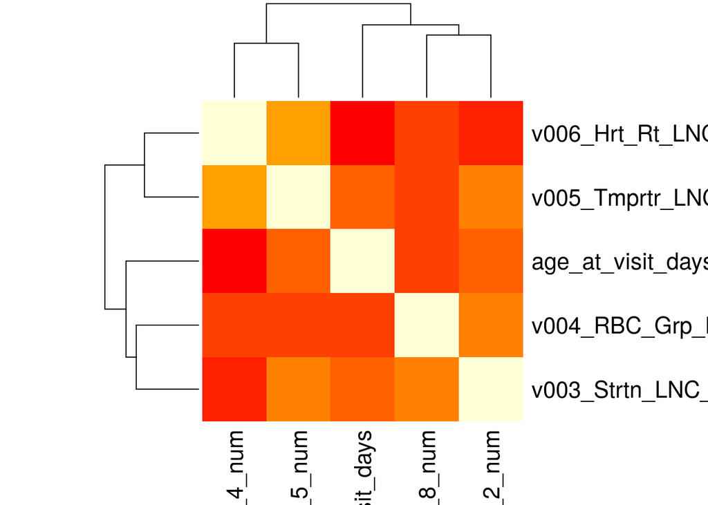

[figure not shown]

`run.R` already creates a dct01 table, so we just need to add columns

## 1. Missing and Unique Values

> Create a column in dct01 (the data dictionary table) that contains the fraction of missing values and another for the number of unique values

Hints for that student:

- Read the following help pages: `?sapply`, `?sum`,‘is.na’
- Remember these rules:
  - `FOO <- summary` creates a an object named `FOO` which is a function that is identical to the built-in function `summary` `FOO(1:10)` is identical to `summary(1:10)`. `FOO` is a valid second argument for `sapply(...)`. **`FOO()` is *not* a valid second argument for `sapply(...)`, keep reading to understand why.**
  - `BAR <- summary(1:10)` creates an object named `BAR` containing the results of `summary(1:10)` which in this case happens to be table of summary statistics. `BAR` is *not* a valid second argviewument to `sapply(...)` because it is not an actual function– it is the result of a function. Exactly like `sqrt(4)` is not a function, but rather the number `2`, though `sqrt` is a function.
  - `BAZ <- summary()` will give you an error because `summary` requires something to summarize. `summary()` is therefore also *not* a valid second argument for `sapply(...)` (just like `FOO()` was not). Even if instead of `summary()` we were using something that doesn’t require an argument like `getwd()` it still cannot be used as a second argument for `sapply(...)` because it’s not a function, it’s a value that gets returned by that function (but you could use `getwd` as a second argument because `getwd` *is* a function)
  - `BAT <- function(xx,...){}` creates an object named `BAT` which is a function that does nothing. `BAT` is a valid (albeit useless) second argument to `sapply(...)`. `BAT()` is *not*. Are you starting to see the pattern yet?
  - `BAX` <- function(xx,…){summary(xx)} creates function `BAX` that returns the same result as the built-in function `summary` but technically speaking is not exactly the same as `summary`. `BAX` is a valid second argument for `sapply(...)` though there’s no reason to use it instead of `summary` itself. `BAX()` is not a valid second argument to `sapply(...)`.
  - `BAY <- function(xx,...){summary(log(xx))}` creates function `BAY` that returns a summary *of the natural log of its first argument*. Now this is a novel combination of functions that is *not* redundant with any existing R function. Which of the following are valid second arguments for `sapply(...)`?
    - `BAY`
    - `BAY()`
    - `BAY(1:10)`
  - `function(xx,...){summary(log(xx))}` seems to just print out the code you just typed in on your console. If you type `BAY`, from the above example, into your console you will get an identical output. Try running `class(function(xx,...){summary(log(xx))})` and then try `class(BAY)`. What do they both say? Except one of them gets dumped to your console and forgotten whereas the other is retained as an object and can be reused later.
    - **Remember that in R anyplace where you can use a value, you can substitute a function that returns that type of value.** For example if `2.71828182845905 - 2` is valid then `exp(1) - 2` will also be valid, as will `exp(2) - 2` (though the latter will give a different result than the first two).
    - This implies that if `BAY(1:10)` returns a result then despite how wierd it looks `function(xx,...){summary(log(xx))}(1:10)` should not only work but it should return the same result! It actually doesn’t, because of the rules governing the order of operations, but you can force `function(xx,...){summary(log(xx))}` to all run before `(1:10)` by using parentheses just as you would in `(10-2)/3` vs `10-2/3`. So try it– what happens when you run `(function(xx,...){summary(log(xx))})(1:10)`? What about `(BAY)(1:10)`?
    - What happens when you run `sapply(...)` with, say, the `mtcars` built-in data.frame as its first argument and `function(xx,...){summary(log(xx))}`? Why did that work? All along I kept saying that `BAT()` is not a valid second argument, `BAT(5)` is not a valid second argument and so on and yet here we are using something followed by parentheses and arguments yet it works?! The reason it works is that the actual requirement is for the second argument to be a function. Most of the time expressions that look like `BAH()` return some kind of value that is not a function. But a few do return a function and that’s what makes them valid for use with `sapply()`. The most common such expression is `function(...){...}` with arguments instead of the first `...` and one or more commands instead of the second `...` and that is what we are using here. In R this is called an anonymous function and in computer science in general it is also called a lambda function.
- You can add a new column to a `data.frame` using any of the following. All give the same result. Pay close attention to quotes (`'`), commas (`'`), dollar signs (`$`) and how many brackets (`[`,`]`) there are and where they are. This is very important.
  - `FOO$BAR <- BAZ`
  - `FOO[['BAR']] <- BAZ`
  - `FOO[,'BAR'] <- BAZ`
- If the column name (in the above example, `FOO`) already exists then it will be replaced with a value you assign to it instead of a new column being created.
- Remember that `dat01` is actual data and for each *column* in `dat01` there exists a *row* that describes it in `dct01`. That is what it means that `dct01` is the data dictionary for `dat01`.
- If something is a TRUE/FALSE vector, it also behaves like a 0/1 vector, which means you can do arithmetic on it.
  - The `mean()` of a vector of 1s and 0s is the same as the fraction of the values that are 1.
  - The `sum()` of a vector of 1s and 0s is the same as the count of values that are 1.
  - If you subtract the fraction positive from 1 you get the fraction negative.

### Answer:

Below I fix some of the formatting in addition to responding to your comments. To see what I changed, in the bash (not R) console you could type `diff KEI_TSCI5050_HW02.R graded_KEI_TSCI5050_HW02.R`.

```r
# dct01$frac<-sapply(dat01,(mean(is.na(Foo)))) = WRONG
# dcto1$frac<- sapply(dat01,mean(is.na(FOO))) = WRONG
# FOO<-summary(dat02)
# dct02<-dct01
# dct02$frac<-mean(is.na(FOO))
```

all of the fractions are the same = something is wrong. need to use sapply but what is the function??? it applied to the summary but not each individual column.

Try it in separate pieces like I do in class– you’ll see that `is.na(FOO)` returns a matrix of TRUE/FALSE values with the same number of rows and columns as the original data.frame. Then when you use the result as an argument to `mean()` you get one single number– the mean of all the `TRUE` (or `1`) and `FALSE` or (`0`) values. Sometimes that’s useful, like if you wanted to know the fraction of the entire data.frame that is missing (37%). But you want a separate fraction for each column. Since you just have one number and are assigning it to a column with multiple rows, this number just gets copied to each row. Again, in other circumstances this is really useful– like when you want to fill in an identical default value all the way down the column without having to type or copy-paste for each row.

sum(is.na(FOO))

```r
# dct02$missing<-sum(is.na(FOO))
# again all of the numbers are the same = something is wrong.  what is summary(dat01) actually showing???
```

See above.

dct02$frac<-sapply (dat01,FOO){mean(is.na())} = wrong

Getting closer!.

dct02<-sapply(dat01,WHAT IS THE FUNCTION??? {mean(is.na())} finally think this is correct

```r
sapply(dat01,function(x){sum(is.na(x))})
```

```
##                 patient_num                  start_date
##                           0                           0
##                  birth_date                      sex_cd
##                           0                           0
##                 language_cd                     race_cd
##                           0                           0
##           age_at_visit_days       v001_unspcfd_asthmtcs
##                           0                        1884
##                    v002_Cgh   v003_Strtn_LNC_2710_2_num
##                        2424                         751
##  v003_Strtn_LNC_2710_2_unit  v004_RBC_Grp_RBC_789_8_num
##                         751                        2060
## v004_RBC_Grp_RBC_789_8_unit v004_RBC_Grp_RBC_789_8_info
##                        2056                        2546
##  v005_Tmprtr_LNC_8310_5_num v005_Tmprtr_LNC_8310_5_unit
##                         751                         751
##  v006_Hrt_Rt_LNC_8867_4_num v006_Hrt_Rt_LNC_8867_4_unit
##                         751                         751
##           v007_Albtrl_Gnrcs
##                        2487
```

```r
dct01$frac <- sapply(dat01,function(x){sum(is.na(x))})
dct01$missing <- sapply(dat01,function(x){mean(is.na(x))})
```

…and to get counts of unique values you would use `sapply(FOO,function(xx) length(unique(xx))`. But yes, the second one, `mean(is.na(xx))` is correct.

Yes, you got it! `sapply()` takes not a function result but a function itself as one of its arguments (the one that says what it is we want to apply). There are two main ways to do that: either give it just the name of the function without the parentheses (one of the few exceptions to the that functions should always be written with parentheses). The other is what you did here – create a temporary un-named function. There is more on that in the original hints bullets-list above.

## 2. Pattern Matching

> Create a column in dct01 with a FALSE for every value of the ‘column’ column that contains the strings ’_date’,’_unit’,’_info’, or ‘patient’ (these are the non-analytic columns) and TRUE otherwise. Create another that is TRUE whenever the previous column is true and in addition the class is character (or char == TRUE).

Hints for the student:

## Answer:

from prior run.R class: grep(‘^v’,dct01[ !dct01$meta & dct01$char , ‘column’ ],val=T)] %>% sapply(function(xx) !is.na(xx),simplify=F) $- matches end of string

```r
FOO <- !grepl('_date$|_unit$|_info$|_patient$', dct01$colum)
dct01$non_analytic <- FOO
```

grepl (’_date$|_unit$|_info$|_patient$’%>%“_class$',dct01$class) = WRONG

```r
BAY <- grepl ("TRUE", dct01$char)
```

grepl (’_date$|_unit$|_info$|_patient$’%>%“_class$’,dct01) = WRONG if (FOO)%>%(BAY), else (FALSE) = WRONG

```r
BAZ <- if (FOO) {dct01$char==TRUE} else {FALSE}
dct01$HW_2 <- BAZ
```